# Intro to Data Science Tutorial

Zachary Dou

Hello! In this tutorial, we will be analyzing the Montgomery County DOT Parking tickets from July 2021 to July 2022.

Many people these days own cars. One of the worst feelings is parking somewhere and paying the meter, only to forget to pay again and come back to that little piece of paper stuck between your windshield wipers. As someone who regularly drives a car living in Montgomery County, I want to see exactly when people are ticketed the most. If I were to park somewhere and forget to pay, when is it most likely that I'll be ticketed? Let's find out!

## 1. Data

This data was found online at the Montgomery County online database, which is linked [here](https://data.montgomerycountymd.gov/Transportation/DOT-Parking-Tickets/uyb2-cfmc). I have gone ahead and uploaded the data as well, so you can directly get the data.

To get started, we need to download some packages that will help us download the data that we need, as well as clean it up for our using.

What we need right now are [pandas](https://pandas.pydata.org/docs/) and [numpy](https://numpy.org/doc/). Pandas is the most commonly used package for data manipulation via it's data structures and operations. Although I do not use numpy heavily in this tutorial, it is very useful for manipulating large arrays and matrices.

```python
import pandas as pd
import numpy as np
import warnings
warnings.filterwarnings("ignore")
```

### Data Scraping and Cleaning

After we have our required libraries, we will use pandas to read in the CSV into a dataframe. We will then use pandas and numpy to manipulate the dataframe so that it has exactly what we need to evaluate.

First, we we use pandas to read in the url, which creates our whole data frame.

```python
url = 'https://raw.githubusercontent.com/zdou22/zdou22.github.io/main/DOT_Parking_Tickets.csv'

#Use read_csv to read in the raw data, creating our data frame
df = pd.read_csv(url)

#For easier readability, we increment the index by 1 so that the first row starts with 1
df.index = np.arange(1, len(df) + 1)

#Prints the first 5 rows of our dataframe, so we can make sure we have everything we need
df.head()
```

|  | Ticket Number | Date/Time | Parking Division | Ticket Location | Meter | Violation Code | Violation Description | Plate Year | Vehicle Make | Plate Month | Vehicle Type | Vehicle Color | Remarks | Issuing Agency |
| --- | --- | --- | --- | --- | --- | --- | --- | --- | --- | --- | --- | --- | --- | --- |
| 1 | 410317412 | 11/09/2021 11:08:00 AM | 2 | L81-7400 ARLINGTON RD | 2810032 | 50.0 | EXPIRED PRKG METER | 2022 | VOLK | 3.0 | 4D | WH | 3 HR PARKING | DOT |
| 2 | 409960622 | 07/31/2021 06:04:00 PM | 8A | 11815 GRAND PARK AVE | NaN | 35.0 | VIOLATION OFFICIAL SIGN ON STREET | 2023 | BMW | 4.0 | SU | BK | NO PARKING 5 PM - 12 AM /. SIGNS POSTED | DOT |
| 3 | 410845164 | 03/31/2022 03:08:00 PM | 4 | 11200 GEORGIA AVE | 1303769 | 17.0 | PRK/STND/STOP RUSH H | 2022 | BMW | 3.0 | SU | BK | NO STOPPING 3:00PM-7PM MON-FRI /. SIGNS POSTED | DOT |
| 4 | 409765193 | 07/01/2021 06:52:00 PM | 3 | G7-8530 CAMERON ST | 3070108 | 50.0 | EXPIRED PRKG METER | 2021 | TOYT | 12.0 | 4D | GO | 2 HR PARKING | DOT |
| 5 | 410670993 | 02/17/2022 10:31:00 AM | 3 | G58-1315 EAST WEST HWY | NaN | 42.0 | UNREG VEH OFF STREET | 2021 | NISS | 11.0 | 4D | GY | EXPIRED TAGS/11 2021/AT SPACE#3584132. TEMPORA... | DOT |

I used numpy to start the index from 1 for better readability, and then deleted rows that won't be used to increase the readability of our table. After this, we use dropna, which will remove rows that have any missing values that we need.

```python
#delete unnecessary columns we won't be using
del df['Parking Division']
del df['Meter']
del df['Plate Year']
del df['Plate Month']
del df['Vehicle Type']
del df['Vehicle Color']
del df['Issuing Agency']
del df['Remarks']

#For any lines that have missing values, we will drop so that we don't have missing data
df = df.dropna()

df.head()
```

[output not shown]

Now, lets check to make sure what each of our columns data types are.

```python
df.dtypes
```

[output not shown]

Pandas allows us to make the Date/Time into an actual datetime data type, which you will see later on is extremely helpful in letting us easily extract what we need.

```python
df['Date/Time'] = pd.to_datetime(df['Date/Time'])
```

## 2. Data Visualization and Analysis

Now that we have our data all cleaned up, we can finally start doing some analysis! First, lets group the dates by the month and see if there is a difference in tickets handed out by month. To create our plot, we can use [matplotlib](https://matplotlib.org/stable/index.html), a package that will help us visualize the data so that we can find trends in the data, that we likely wouldn't be able to tell based off of the dataset alone.

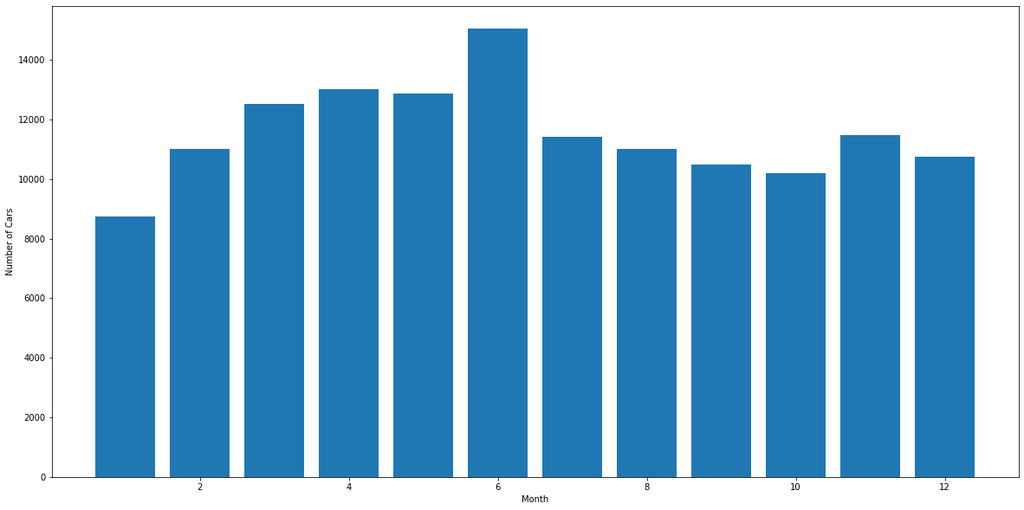

```python
import matplotlib
import matplotlib.pyplot as plt

#resize our plot for easy readability
plt.figure(figsize=(20,10))

#Use value_counts to find how many of each unique value we have. Here, it would find how many tickets were in each month
counts = df['Date/Time'].dt.month.value_counts()

#set our x values to be the month
x = counts.index
#set our y values to be the number of tickets per month
y = counts.values

#create a bar graph
plt.bar(x,y)

#label our axes
plt.xlabel('Month')
plt.ylabel('Number of Cars')
plt.show()
```

From this graph we have made with the months, we see the highest number of tickets coming from June, and the lowest in January. This low point could be due to the cold, where many people are staying inside more. The high in June could possibly be due to school being out, and there is an influx of both high schoolers who can drive, as well as college students coming back from classes out of state.

Now lets try finding out which days of the week are ticketed the most. We can do this similarly to above, but using dt.dayofweek instead of dt.month. With this, Monday is 0 and goes all the way to 6.

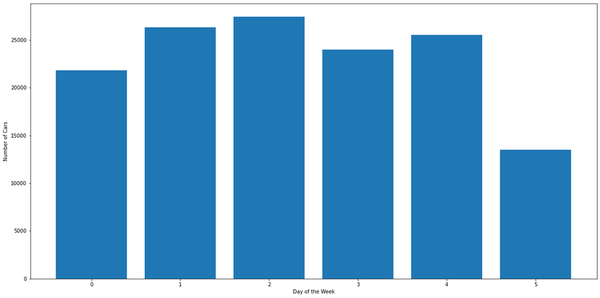

```python
#The same procedure, but using dayofweek instead
plt.figure(figsize=(20,10))
counts = df['Date/Time'].dt.dayofweek.value_counts()
x = counts.index
y = counts.values
plt.bar(x,y)
plt.xlabel('Day of the Week')
plt.ylabel('Number of Cars')
plt.show()
```

Here, we find something very interesting! There are no tickets given out on Sundays. This is likely due to even metered parking being free on Sundays. However, this doesn't explain why there aren't tickets being handed out for other infractions, such as blocking a fire hydrant. There seems to also be significantly less tickets on Saturday. This is could be due to less officers working on Saturdays, resulting in less tickets.

Now lets do the same thing, but with the time.

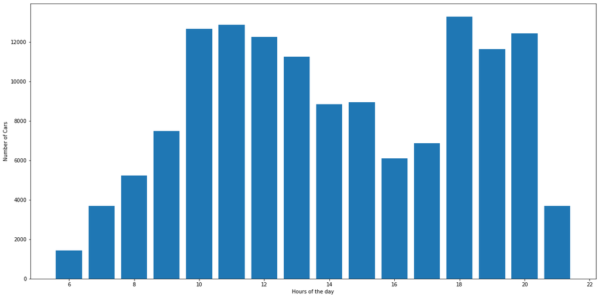

```python
plt.figure(figsize=(20,10))
counts = df['Date/Time'].dt.hour.value_counts()
x = counts.index
y = counts.values
plt.bar(x,y)
plt.xlabel('Hours of the day')
plt.ylabel('Number of Cars')
plt.show()
```

Here, we can clearly see the trend of steadily increasing until 11am, where it then starts to diminish until 4pm. It then dramatically rises at 6pm, and stays relatively high until 9pm. There are no tickets that have been noted outside of 6am to 9pm, as this is likely when the DOTS officers are no longer working. I think that the spike at 11am comes from people forgetting after parking for their job, which slowly dies down as they have already recieved the ticket. Then once people are leaving their jobs and driving elsewhere, this causes the influx of tickets at 6pm.

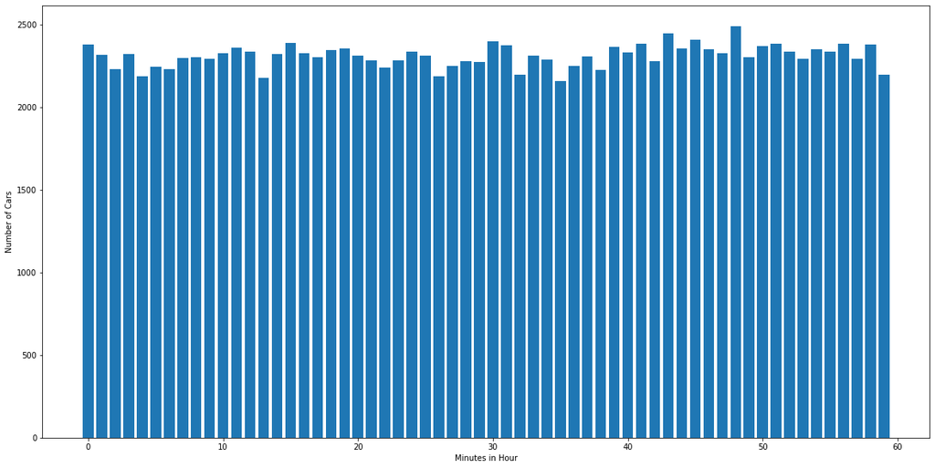

```python
plt.figure(figsize=(20,10))
counts = df['Date/Time'].dt.minute.value_counts()
x = counts.index
y = counts.values
plt.bar(x,y)
plt.xlabel('Minutes in Hour')
plt.ylabel('Number of Cars')
plt.show()
```

With the minutes, there is no noticeable difference, which makes sense. The ticket happens whenever the DOTS worker sees the vehicle, and this would be random.

Below, we want to find out if there is a difference between car brands. Are perhaps DOTS workers more biased to ticket some brands than others? Because there are so many brands, I have limited our dataset so that we exclude models that have very few tickets, given how large our dataset is.

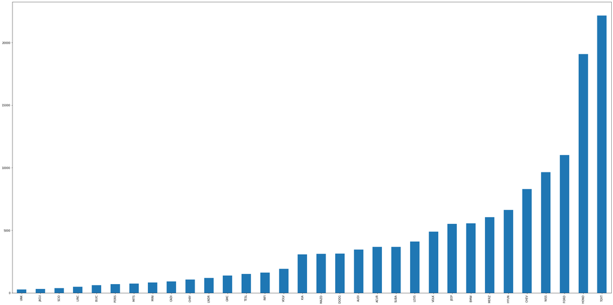

```python
partial_table = df
counts = partial_table['Vehicle Make'].value_counts()

#Because counts gives us the number of cars per brand, we find the brands that have greater than 200 tickets
partial_table = partial_table.loc[partial_table['Vehicle Make'].isin(counts.index[counts>200])]
plt.figure(figsize=(40,20))

#A different way of creating our plot
partial_table['Vehicle Make'].value_counts().sort_values().plot(kind='bar')
```

Great! Now let's find out what are the most common tickets for.

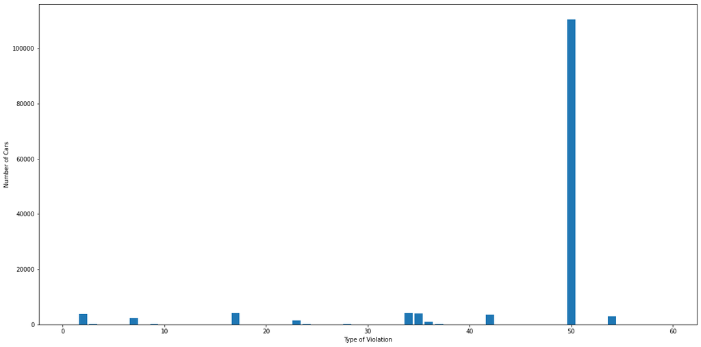

```python
plt.figure(figsize=(20,10))
counts = df['Violation Code'].value_counts()
x = counts.index
y = counts.values
plt.bar(x,y)
plt.xlabel('Type of Violation')
plt.ylabel('Number of Cars')
plt.show()
```

It seems that there is one violation that happens far more frequently than others, so let's make this graph logarithmic so that we can better see all the other violations.

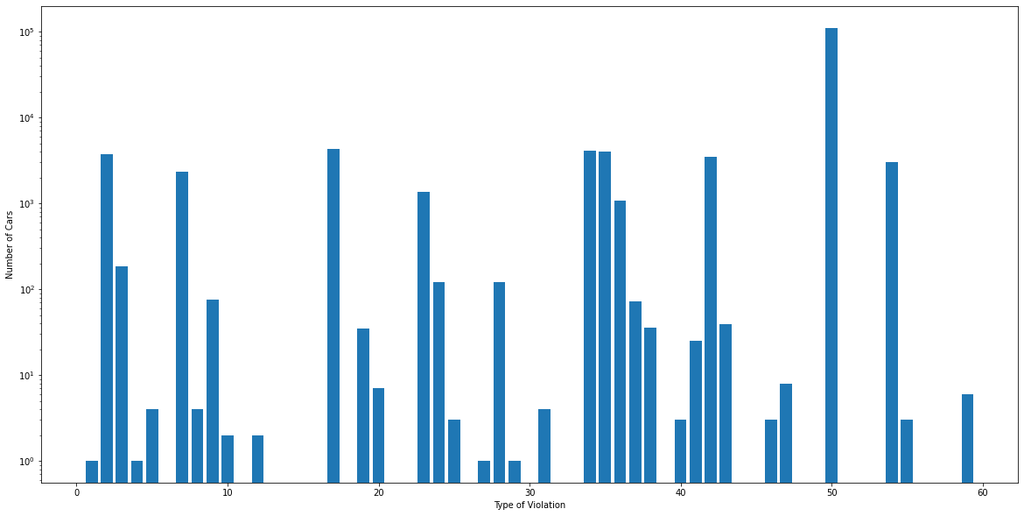

```python
plt.figure(figsize=(20,10))
counts = df['Violation Code'].value_counts()
x = counts.index
y = counts.values

#mattplotlib has many parameters to allow us to adjust our graph
plt.bar(x,y, log = True)
plt.xlabel('Type of Violation')
plt.ylabel('Number of Cars')
plt.show()
```

Now let's find out what each of these are by printing a shortened table with the violation code corresponding to the violation description.

```python
df_violations = df[['Violation Code','Violation Description']].value_counts()
df_violations
```

```
Violation Code  Violation Description
50.0            EXPIRED PRKG METER                    110441
17.0            PRK/STND/STOP RUSH H                    4269
34.0            NPAT - ON STREET                        4137
35.0            VIOLATION OFFICIAL SIGN  ON STREET      3965
2.0             UNREGISTERED VEH  ON STR                3712
42.0            UNREG VEH OFF STREET                    3496
54.0            RES PRKG PERMIT ONLY                    3027
7.0             OVERTM PRKG - STREET                    2363
23.0            NO STANDING - ON STR                    1354
36.0            OFFICIAL SIGN OFF ST                    1064
3.0             EMRGNCY NPAT - STREE                     184
24.0            DOUBLE PARKED - STRE                     122
28.0            OPP TRAFFIC - ON STR                     122
9.0             IMPEDING TRAFF/SAFET                      76
37.0            NPAT OFF STR                              72
43.0            HANDICAP PKG AREA                         39
38.0            NT IN PRK SPC OFF ST                      36
19.0            WITHIN 15 FT HYDRANT                      35
41.0            OVR 24 HRS OFF STREE                      25
47.0            IMPEDING TRFF OFF ST                       8
20.0            WITHIN 20 FT CROSSWK                       7
59.0            PARKED ON SIDEWALK                         6
31.0            NO STND/STOP BUS ST                        4
8.0             WTHIN 5 FT DRIVEWAY                        4
5.0             OVER 24 HRS - STREET                       4
40.0            BLK ANTHR VEH OFF ST                       3
25.0            NO STND/PRK FIRE LN                        3
46.0            UNATTD/UNSEC VEHICLE                       3
55.0            IMPDG TRFF/SAFE ALLY                       3
12.0            PRK/STND/STOP CROSS                        2
10.0            PRK/STND/STOP SIDEWA                       2
29.0            BLK ANTHR VEH - STRE                       1
27.0            PARK MORE 1 FT CURB                        1
4.0             COMM VEH ADJ RES/SCH                       1
1.0             SNOW EMRGNCY - STREE                       1
dtype: int64
```

Now we can see that the most amount of violations by far are expired parking meters.

What if we wanted to compare when people get ticketed differently on an hourly basis, based on the month? For this, we can use a violin plot. This will show us where our data is distributed. For this, we will need to use [seaborn](https://seaborn.pydata.org/). Seaborn is based off of matplotlib, which we were using earlier. However, seaborn is better for creating more indepth visuals.

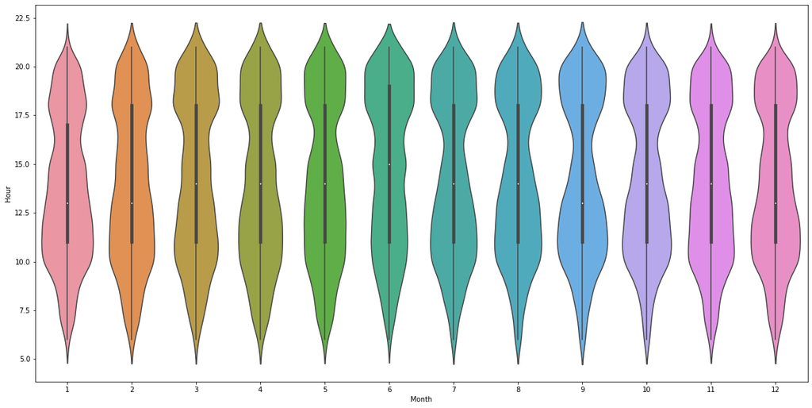

```python
import seaborn as sns
plt.figure(figsize=(20,10))
y = df['Date/Time'].dt.hour
x = df['Date/Time'].dt.month

sns.violinplot(x,y)
plt.xlabel('Month')
plt.ylabel('Hour')
```

From this violin plot, the bulges are where there is a high concentration of data points. From this we can tell that in the months of July to October, the observation we made above where the number of tickets drops off from 2-5pm is most prominent, and the concentration is much more centered around 11am and 6pm. However, something interesting to note is that it is a much more even distribution in the other months. Another point that is interesting is in the coldest months of January and February, there are less tickets at the later hours, which one reason could be because people are staying in more than going out.

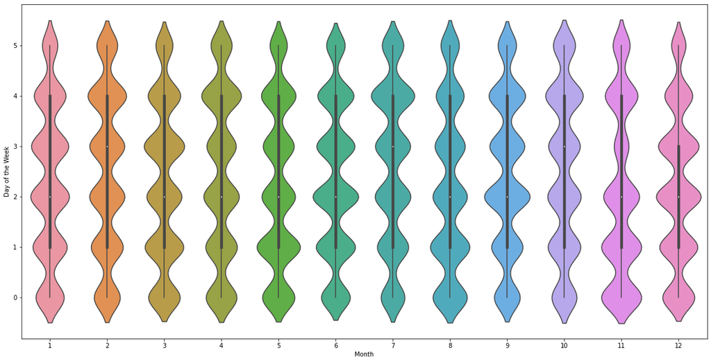

```python
plt.figure(figsize=(20,10))
y = df['Date/Time'].dt.dayofweek
x = df['Date/Time'].dt.month

sns.violinplot(x,y)
plt.xlabel('Month')
plt.ylabel('Day of the Week')
```

In this violin graph, we compare when people get ticketed based off of the day of the week. Although we can't make many inferences from this, one interesting thing of note is that Thursdays in November is significantly smaller than any of bumps we see. This is almost assuredly because of Thanksgiving, which is something interesting to take note of.

# Conclusion

From these plots we've made, we have found various correlations as to the time, day of the week, and the month of when parking tickets are given in Montgomery County. This is something that can be used by any resident to have a better understanding of when it is absolutely necessary to pay, and when it is might be fine if you accidentally forget to pay your meter. We also have learned information beyond just parking tickets, information that we extrapolated by factors such as car brands which can give us deeper insights on our community.

```python
!wget -nc https://raw.githubusercontent.com/brpy/colab-pdf/master/colab_pdf.py
from colab_pdf import colab_pdf
!cp "./drive/My Drive/Colab Notebooks/FinalTutorial.ipynb" ./
!jupyter nbconvert --to HTML '*FinalTutorial.ipynb'
```